# Behavioral Risk Factor Surveillance System (BRFSS) Data Analysis Project

Ami S

15/06/2021

## *BRFSS Overview:*

- The Behavioral Risk Factor Surveillance System(BRFSS) is a collaborative project between all the states in the United States(US) and participating US territories and the Centers for Disease Control and Prevention(CDC).
- The Population Health Surveillance Branch of CDC supports and administered BRFSS. BRFSS is an ongoing surveillance system designed to measure behavioral risk factor for the non-institutionalized adult population(18 years of age and older) residing in the US.
- It was established in 1984 initially with 15 states, However, BRFSS now collects data from all 50 states as well as the District of Columbia and three U.S. territories.
- Each Year about 400,000 adult interviews are completed by BRFSS, which makes BRFSS as one one the largest continuously conducted health survey system in the world.

## *Objective:*

- The objective of this survey is to collect uniform, state-specific data on preventive health practices and risk behaviors that are linked to chronic diseases, injuries, and preventive infectious diseases that affect the adult population.

## *Data collection:*

- BRFSS is a cross-sectional telephone survey that state health departments conduct monthly over landline telephones and cellular telephones with a standardized questionnaire and technical and methodological assistance from CDC.
- BRFSS is conducted in two ways:
  1. Landline telephone surveys: Here, the interviewers collect data from randomly selected adult in a household.
  2. Cellular telephone surveys: While in this version the interviewers collect data from an adult who participated by using a cellular telephone and resides in a private residence or college housing.
- Disproportionate stratified sampling (DSS) has been used for the landline sample and the cellular telephone respondents are randomly selected with each having equal probability of selection.
- The dataset we are working on contains 330 variables for a total of 491, 775 observations in 2013, while the missing values denoted by “NA”.

## *References:*

```
For more details on the data collection procedure and other related information
following links are available.
```

- BRFSS web site: http://www.cdc.gov/brfss/
- BRFSS Questionnaire (Mandatory and Optional Modules): http://www.cdc.gov/brfss/questionnaires/pdf-ques/2013%20BRFSS_English.pdf
- BRFSS Codebook: http://www.cdc.gov/brfss/annual_data/2013/pdf/CODEBOOK13_LLCP.pdf
- BRFSS Guide to Calculated Variables: http://www.cdc.gov/brfss/annual_data/2013/pdf/2013_Calculated_Variables_Version15.pdf
- BRFSS Guide to Optional Modules Used, by State: http://apps.nccd.cdc.gov/BRFSSModules/ModByState.asp?Yr=2013

## *Generalization:*

- Further getting into more exploration of the BRFSS data, one must understand the how this research can be applied based on the Generalization of the data.
- Since the survey was conducted across all the 50 US states including the union territories and collected through random sample, it can be generalized to the broader US population of interest.
- The Survey consist of 491,775 U.S adults aged 18 years or older, and based on the large stratified random sample.
- Any potential biases are largely associated with non-response, incomplete interviews, missing values and convenience bias.
- However, some information might be missing since there are chances that potential respondents may not have access to the landline or cellphones resulting in study biases, however, they play less role, since this research tries to collect as many data as possible.

## *Causality:*

- BRFSS is an observational study/exercise, with no explicit random assignments to treatments. Hence, through this study one can only establish correlation/associations between variables if any but no causation.

### *Research Questions:*

**Research Question 1:**

```
Does smoking play any role in causing asthma? Is there any correlation between Asthma and Smoking?
If there is any correlation than does the asthma treatment can be affected by smoking? Does it leads to
longer treatment period? We also analyse how the corrlation of asthma occurrance and its treatment period
are different female and male?
```

**Research Question 2:**

```
Is there any correlation between sleep time and Depression? Does lack of sleep cause depression?
  If so how does it have similar effect on both sexes or different??
```

**Research Question 3:**

```
Does the marital status have any effect on the mental health of an individual?
Is there any correlation between the marital status and the mental health of individuals?
If there is how it affects both sexes, and is there any demographic similarities in across different
regions of US?
```

### *Exploratory Data Analysis:*

```
Loading the required packages and Data for this Analysis.
```

```r
# loading the required packages:

library(dplyr)
library(ggpubr)
```

```r
library(ggplot2)


# Loading the Data:

load("C:/Users/admin/Downloads/Bfrss_2013.Rdata.Rdata")
```

### **Research Question 1:**

```
Does smoking play any role in causing asthma? Is there any correlation between Asthma and Smoking?
If there is any correlation than does the asthma treatment can be affected by smoking? Does it leads to
longer treatment period? We also analyse how the corrlation of asthma occurrance and its treatment period
are different female and male?
```

```r
# Loading and sorting the data according to the required variables:

q2 <- brfss2013 %>% select(sex, smokday2,asthmage, asthmed3) %>%
  filter(!is.na(sex), !is.na(smokday2),!is.na(asthmage), !is.na(asthmed3)) %>%
  group_by(sex,smokday2, asthmage, asthmed3) %>%
  summarise(count=n()) %>%
  mutate(perc=count/sum(count))
```

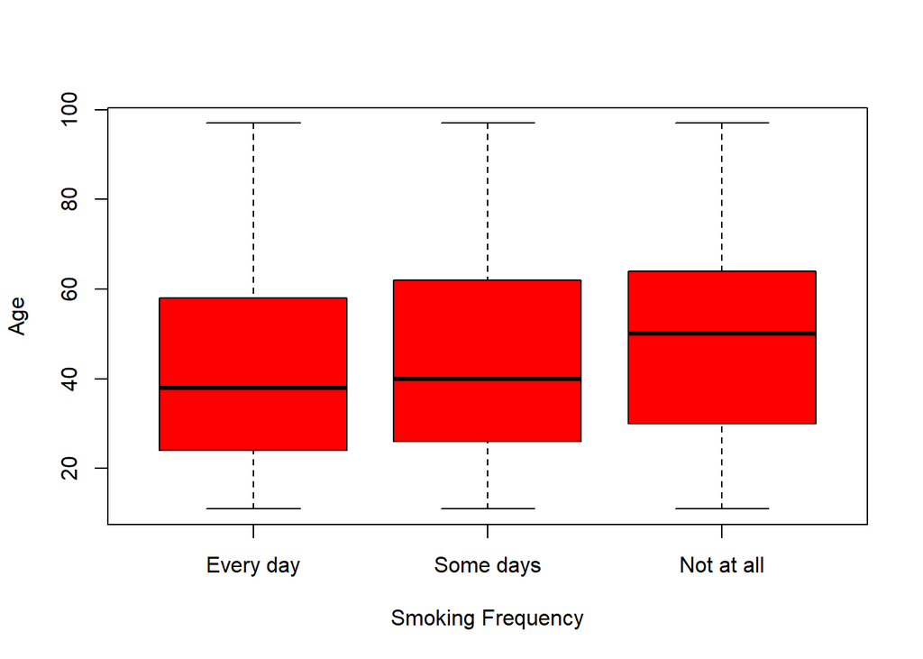

```
The above plot show that smoking and occurrence of asthma have mild correlation.

Now, comparing indivduals based on sexes, on how the frequency of smoking affects the occurance of
asthma in them and how they vary on both male and female:
```

```r
  plot(q2$smokday2, q2$asthmage, col = 'red' ,xlab = 'Smoking Frequency', ylab = 'Age', title = 'Smoking and Asthma disease correlation')
```

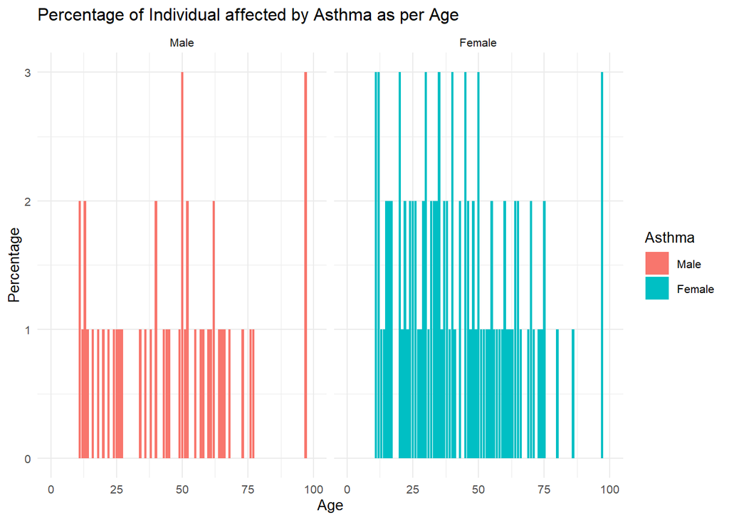

```
 In the  the above plot, we see that female are more affected by asthma than male.

 Now lets look at the data of smoking frequency and does it affects the medication period, to find if
 there is any correlation between the frequency and the recovery of asthma in both male and female, as
 follow:
```

```r
ggplot(q2, aes(x =asthmage, y = perc, fill = factor(sex))) +
  geom_bar(stat="identity", Position = 'dodge') +
  labs(x = "Age", y = "Percentage", fill = "Asthma", title = 'Percentage of Individual affected by Asthma as per Age') +
  theme_minimal(base_size = 10) + xlim(0,100) + facet_grid(. ~ sex)
```

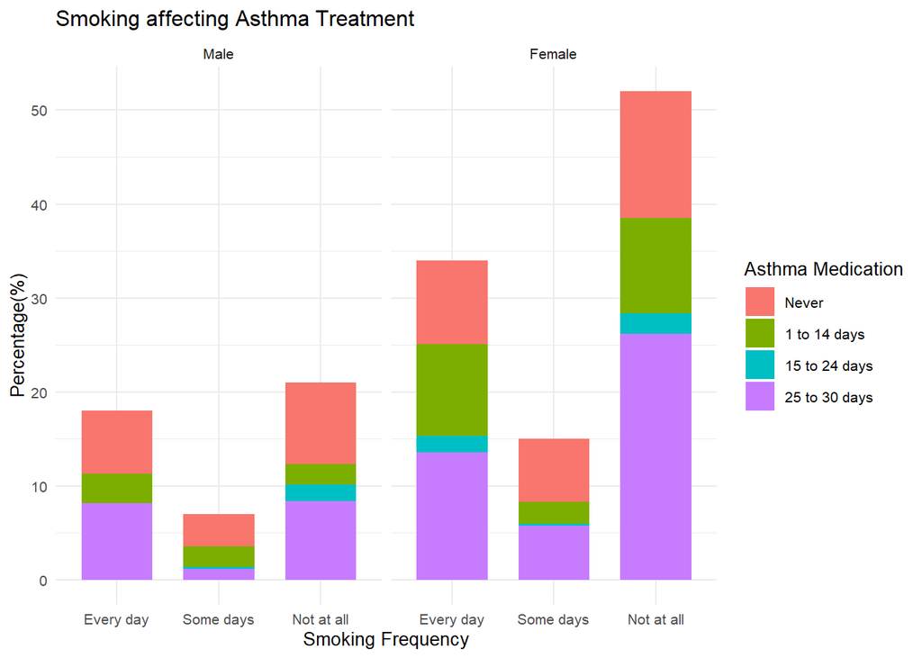

```
In the above plot, it reveals that smoking does play a minor role in the recovery period however, we can
clearly see that female takes long time of recovery than male who recovery faster. There might be other
variables that can be a reason, since smoking is not that strongly correlated with the asthma recovery
period.
```

```r
ggplot(q2, aes(x = factor(smokday2), y = perc, fill = factor(asthmed3))) +
  geom_bar(stat="identity", width = 0.7) +
  labs(x = "Smoking Frequency", y = "Percentage(%)", fill = "Asthma Medication",
       title = 'Smoking affecting Asthma Treatment') +
  theme_minimal(base_size = 10) +
  facet_grid(. ~  sex)
```

#### *Conclusion:*

[output not shown]

### **Research Question 2:**

```
  Is there any correlation between sleep time and Depression? Does lack of sleep cause depression?
  If so how does it have similar effect on both sexes or different?
```

```r
 # Loading and sorting the data for sleep and Depression variables and  comparing it with the general health for both sexes:

  T1 <- brfss2013 %>% select(sex, sleptim1, genhlth, misdeprd) %>%
  filter(!is.na(sex), !is.na(genhlth),!is.na(misdeprd)) %>%
  group_by(sex,sleptim1, genhlth, misdeprd) %>%
  summarise(count=n()) %>%
  mutate(perc=count/sum(count))
```

```
Creating a plot that will help in assessing how the sleep affects differently depending on the health
status and how different it affects both male and female.
Plotting about the sleep time and Depression Boxplot to see of there is any realtion and if there is any
how the variation is across.
```

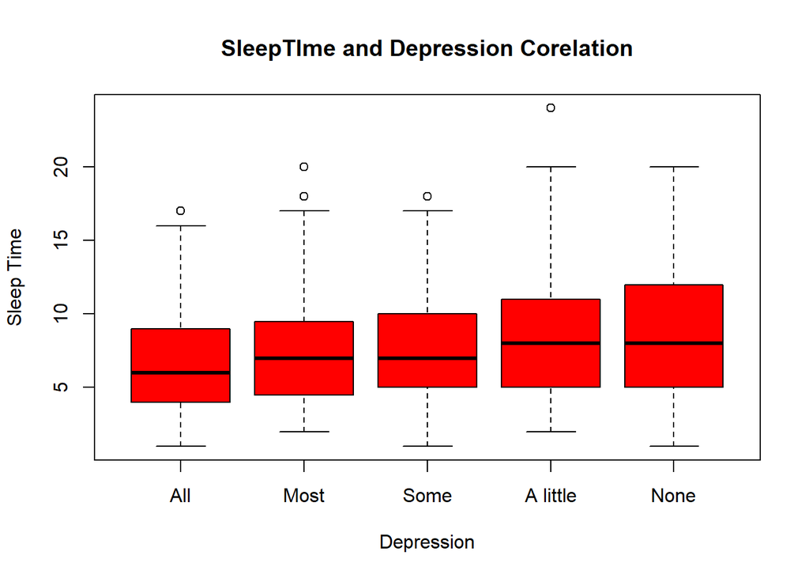

[output not shown]

```r
plot(T1$misdeprd, T1$sleptim1, data = T1, xlab = 'Depression', ylab = 'Sleep Time',
     main = "SleepTIme and Depression Corelation", col = "red")
```

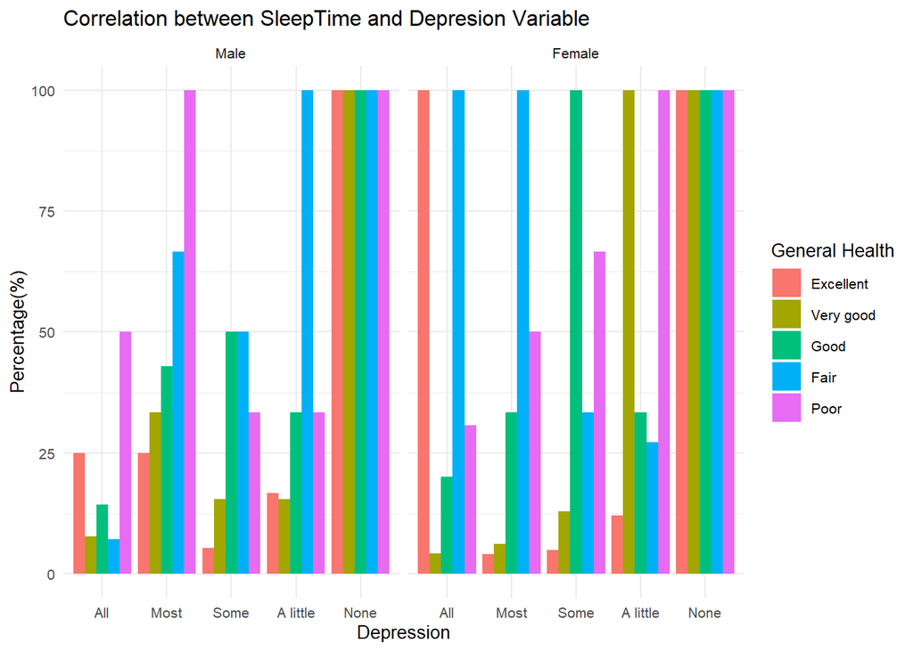

```r
ggplot(T1, aes(x = factor(misdeprd), y = perc*100, fill = factor(genhlth))) +
  geom_bar(stat="identity", position = 'dodge') +
  labs(y = "Percentage(%)", x = "Depression", fill = "General Health", title = 'Correlation between SleepTime and Depresion Variable') +
  theme_minimal(base_size = 10) + facet_grid(. ~ sex)
```

This plot shows the frequency of depression within the general health of the population and how differently it affects male and female.

Now, Comparing the data with respect to how it affects both male and female.

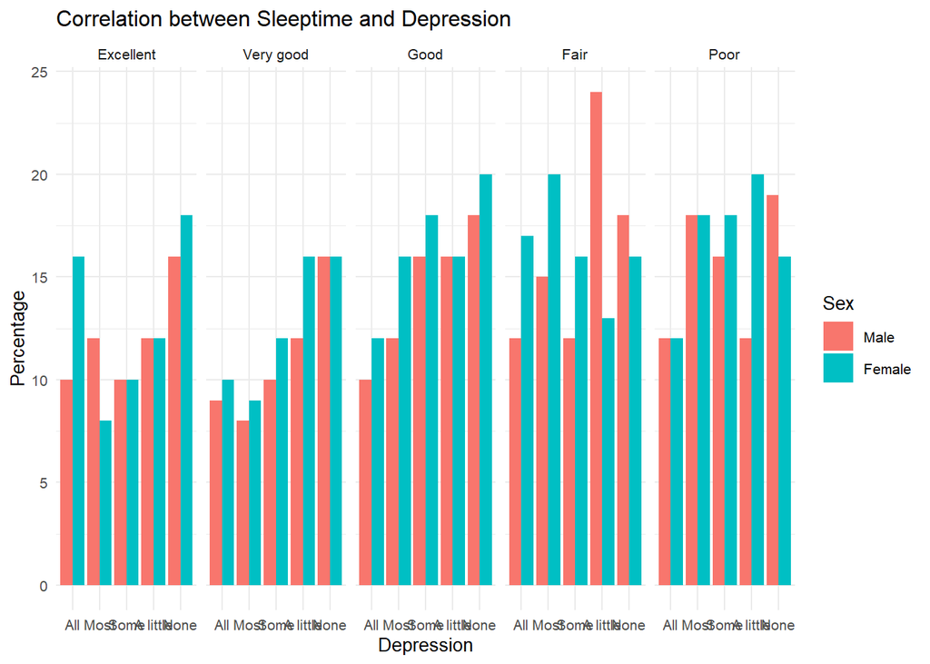

```r
ggplot(T1, aes(x = misdeprd, y = sleptim1 , fill = factor(sex))) +
  geom_bar(stat="identity", position = 'dodge') +
  labs(x = "Depression", y = "Percentage", fill = "Sex", title = 'Correlation between Sleeptime and Depression') +
  theme_minimal(base_size = 10) + facet_grid(. ~ genhlth)
```

#### *Conclusion:*

```
There are some fluctuations seen in the graph and it shows almost similar effect on both male and female
and how it affects the metal health of both sexes.
The data shows that sleep time show correlation to depression however, the correlation and mild and not
strong. It seems it is not major causes of depression, however it might lead to its severity but not one
of main cause.
```

### **Research Question 3:**

```
Does the marital status have any effect on the mental health of an individual?
Is there any correlation between the marital status and the mental health of individuals?
If there is how it affects both sexes, and is there any demographic similarities in across different
regions of US?
```

```r
  # Loading the required data for this research question:

S1 <- brfss2013 %>% select(iyear, sex, X_state, marital, menthlth) %>%
  filter(!is.na(X_state), !is.na(sex),!is.na(marital), !is.na(menthlth)) %>%
  group_by(sex, menthlth, marital, X_state) %>%
  summarise(count=n()) %>%
  mutate(perc=count/sum(count))
```

```
For demographic research lets divide the states based on the regions:
```

```r
regionlist <- list(South = c("Texas","Oklahoma","Arkansas","Louisiana","Mississippi","Alabama","Georgia","Florida","Tennessee","Kentucky","West Virginia","Virginia","North Carolina","South Carolina", "Maryland","Delaware"),
                   Northeast = c("Maine","New Hampshire","Vermont","Massachusetts","Connecticut","Rhode Island","New York","New Jersey","Pennsylvania"),
                   Midwest = c("Ohio","Michigan","Illinois","Indiana","Wisconsin","Minnesota","Iowa","Missouri","North Dakota","South Dakota","Nebraska","Kansas"),
                   West = c("Alaska","Hawaii","Washington", "District of Columbia","Oregon","California","Nevada","Idaho","Utah","Arizona","New Mexico","Colorado","Wyoming","Montana"),
                   Territory = c("Guam", "Puerto Rico")
)

S1$Region <- sapply(S1$X_state,
                    function(x) names(regionlist)[grep(x,regionlist)])
```

```
Lets look at he statistics of the data and how it varies:
```

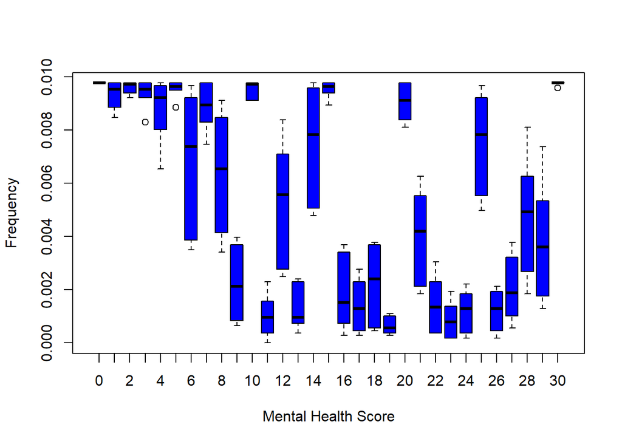

```
Above plot show the Frequency of the mental health Score.We can see that there are lot of variations in
the mental health score across the population.
```

```r
P <- as.data.frame(prop.table(table(S1$marital, S1$menthlth)))

plot(P$Var2, P$Freq,col = "blue", xlab = 'Mental Health Score', ylab = 'Frequency', title = 'Probability of Mental Health')
```

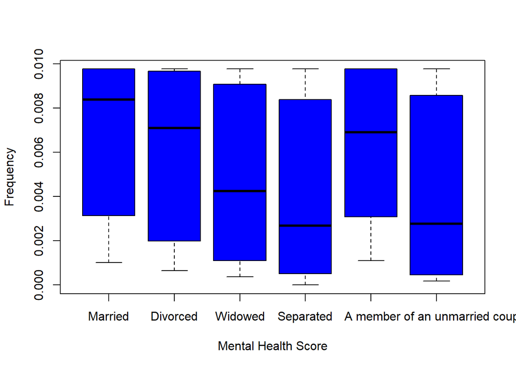

```
Above Plot show the frequency of marital Status within in society across the population.


Now, Plotting the graph to view first individually the variables marital status and mental health and its
affects on the health followed by comparing them together:
```

```r
plot(P$Var1, P$Freq,col = "blue", xlab = 'Mental Health Score', ylab = 'Frequency', title = 'Probability of Mental Health')
```

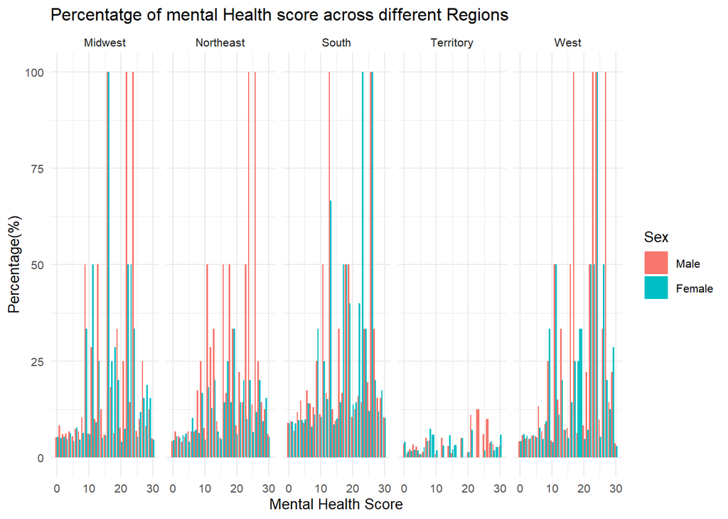

[output not shown]

```r
ggplot(S1, aes(x = (menthlth), y = perc*100 , fill =factor(sex))) +
  geom_bar(stat="identity",position = 'dodge' ,width = 0.9)  +
  labs(x = "Mental Health Score", y = "Percentage(%)", fill = "Sex",
       title = 'Percentatge of mental Health score across different Regions') +
  theme_minimal(base_size = 10) + facet_grid(. ~ Region)
```

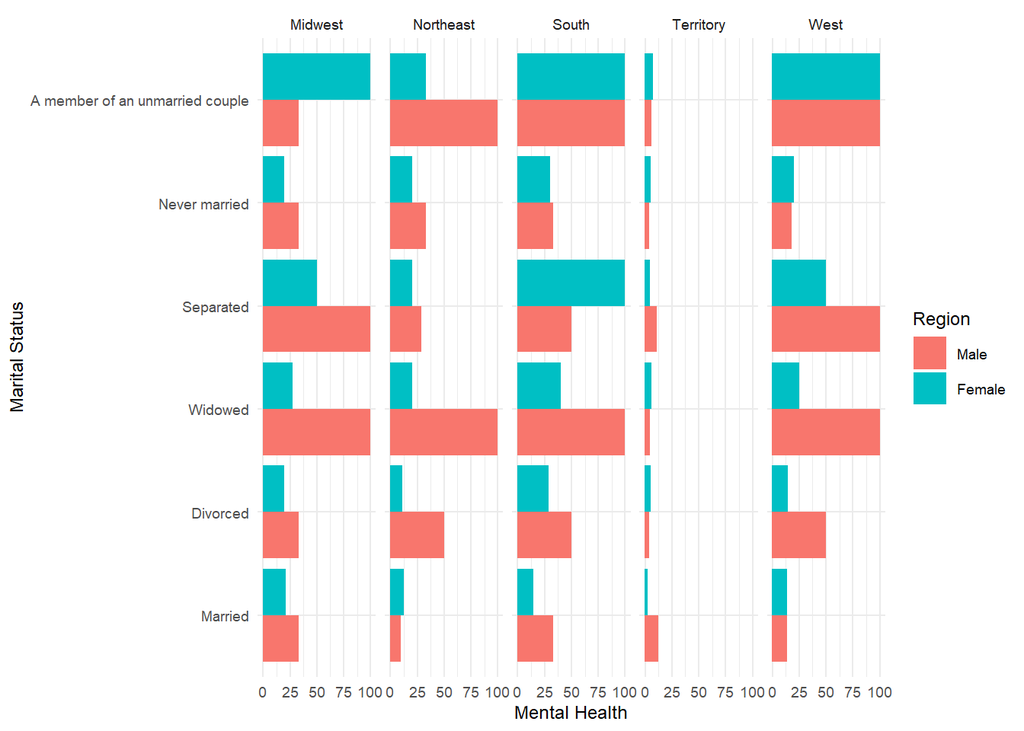

```
Above plot shows how marriage status and mental health are correlated in respect to region and sexes
we can see more variation in males than in female.
```

```r
ggplot(S1, aes(x = factor(marital), y = perc*100 , fill = factor(sex))) +
  geom_bar(stat="identity", position = 'dodge') +
  labs(x = "Marital Status", y = "Mental Health", fill = "Region") +
  theme_minimal(base_size = 9) + facet_grid(. ~ Region) + coord_flip()
```

[figure not shown]

```r
ggplot(S1, aes(x = factor(marital), y =factor(menthlth ), fill = factor(sex))) +
  geom_bar(stat="identity", position = 'dodge')  +
  labs(x = "Marital Status", y = "Mental Health", fill = "Region", title = 'Correlation between Mental Health Score and Marital Status in Different regions in US')  +
  facet_grid(. ~ Region) +facet_wrap(~ Region, nrow =5, scales = 'free')  + coord_flip()
```

#### *Conclusion:*

[output not shown]